# Summary Report for 2 improvements reproductions in Local BA

Wangshi in orbbec @ 2021.6.15

code github : https://github.com/wangshizhang/ORB_SLAM2_mod

## Introduction

根据苏丹哥提供的一篇paper "Good Graph to Optimize: Cost-Effective,Budget-Aware Bundle Adjustment in Visual SLAM"，其中做了三个改进。代码已开源，github地址https://github.com/ivalab/gf_orb_slam2

- 1、Good Feature Select。针对local BA中，对于observation也就是待优化图中edge的筛选。
- 2、Multi-index Hash。针对local BA中，由共视产生的特征点的进一步筛选。
- 3、Good Graph Select。针对local BA中，优化图的整体筛选。

现已对其中Good Feature Select以及Multi-index Hash进行了复现，结果有一定的参考性，将进行代码复现思路，复现结果的总结。

## Code Details Instructions

这一部分将对代码实现思路和细节上进行说明，所有代码都将基于原始Orb-slam2（ https://github.com/raulmur/ORB_SLAM2 ）进行改进。

### Good Feature Select

#### The ideas and detailed process

具体idea的理解过程请参考 “Good Feature Selection for Least Squares Pose Optimization in VO/VSLAM”这篇paper。 我将简单说明这个idea的主要思路如下。

- 1、从object function也就是误差的二阶模出发，我们可以得到其中(map points)地图特征点的误差对于相机位姿误差的影响，将体现为基于雅克比的推导式（参考paper的推导即可），其意义是map points的方差到特征点方差的传递。简单来说，有一些map points对camera pose的求解影响大，有一些影响小。因此我们需要筛去那些影响大的map points的观测，也就是待优化图中的edge。
- 2、为了衡量这个影响，我们对所推导出的矩阵需要设计一个指标进行衡量。paper中探讨了多种常见指标，最后选择了LogDet作为使用指标。
- 3、为了加速基于LogDet的筛选过程，论文设计了greedy policy，从而减小了search space。

以上就是这篇paper主要的实现过程，也就是代码实现的主要思路

#### Code Structure

代码主要过程实现在Local BA过程，更具体来说，实现在Optimizer.cc 的 Optimizer::LocalBundleAdjustment 函数中(Line 780+)。将在原始optimizer的图已经构建好之后，对每一条edge进行进一步的筛选，剔除不要的edge。具体过程分为两个部分。

- 1、计算paper中所推导的，基于每一次观测的H_c矩阵。基于这个矩阵和LogDet指标，计算出这条edge的score并存放。
- 2、根据每一条edge的score进行筛选，存放最后的结果

代码过程实现可参考源码中的注释，Mono和Stereo结构相似。

### Multi-index Hash

#### The ideas and detailed process

具体idea的理解过程请参考 “Low-latency Visual SLAM with Appearance-Enhanced Local MapBuilding” 这篇paper，我将简单说明这个idea的主要思路如下。

- 1、原始ORB-SLAM2在构建优化图的时候采用了共视（Covisibility），但共视图意味着随着KeyFrame数量的上升，比较靠前的KeyFrame的共视点对于当前KeyFrame的优化的帮助是有限的。因此paper提出，除了共视之外，再引入一个基于相似度的map points筛选，即我们希望LocalBA的map points要和当前KeyFrame更接近一点。
- 2、那么如何筛选出和当前KeyFrame相似的map points？这篇paper提出了基于hash的多段匹配，即将ORB的256位特征进行分段筛选，对当前KeyFrame的可观测到的map points进行分段匹配，每一个point都能通过Multi-index Hash匹配得到一些和它局部上相似的map points，然后求并集即可。
- 3、paper中进一步采用了和Good Feature Select相似的greedy策略，对得到的解进行了进一步筛选

以上就是这篇paper的主要思路，代码实现思路也是一致的。

#### Code Structure

代码主要过程实现在Local BA过程，更具体来说，实现在Optimizer.cc 的 Optimizer::LocalBundleAdjustment 函数中（Line 490+)。将在optimizer构建优化图之前，针对其基于共视的Local Map Points先进行筛选。具体过程分为三个部分。

- 1、对基于共视（Covisibility）的Local Map Points构建Multi-index Hash Table，就是把每一个ORB分为多段，放入每一段所对应的hash table。每一个Hash Table，key是256位被分为多段后的值（比方256位被分为32段，那么每一段就是8位，值在[0,255]之中），value是对应map points的索引，即如果有多个map points在某一段上是一致的，那么相对应这一段的hash value就是这一些map points的索引list。
- 2、对当前KeyFrame的map points做分段匹配查找，即每一个point都可以获得一些和它局部相似的点，把所有point的结果求并集、
- 3、存放最后所筛选得到的map points作为Local Map Points。

注意，我这里没有实现greedy的筛选策略，基于两个考虑。第一，Good Feature Select中，LogDet Greedy的效果不是很明显；第二，从结果看，特征点的筛选比例已经比较明显，因此没有做进一步的筛选

## Results of improvements

### Good Feature Selection

#### Time Comparison

这里展示的是采用了Good Feature Select和原始ORB-SLAM2在不同dataset上各阶段消耗时间的比值。可以看出，Good Feature Select对于整个过程的加速效果并不是十分显著（即比值小于1），在一些dataset上甚至更加耗时。并没有获得预期的加速效果。

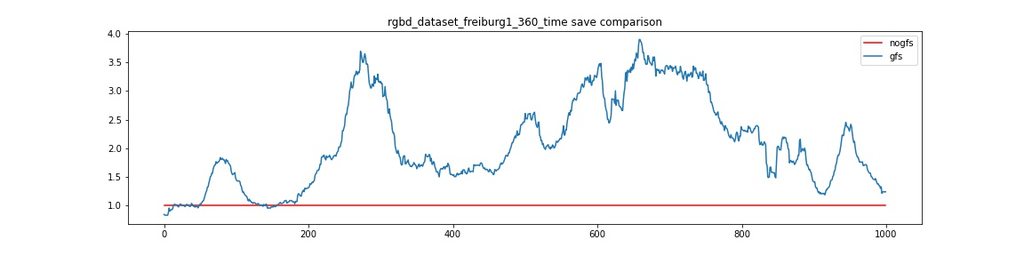

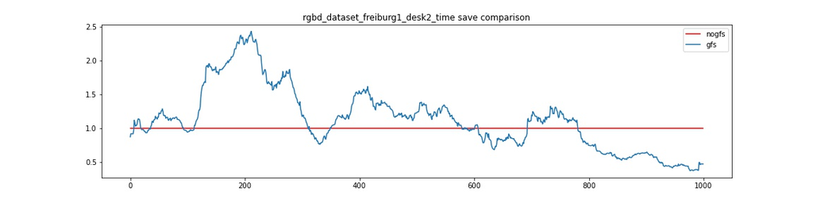

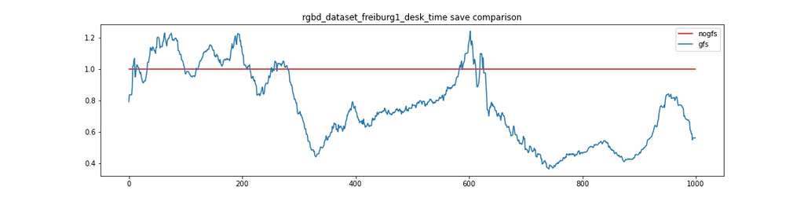

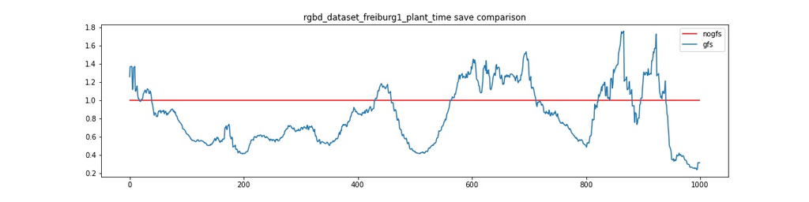

#### Error comparison

但我们不止希望改进是单纯的提速，否则我们只需要随意减小问题规模就可以。因此我们需要对精度进行衡量。

这里采用误差的平均和方差来画图，越靠近左下角意味着越好。

可以看出，Good Feature Select虽然牺牲了一定的精度，但并没有获得预期的速度上的提升。

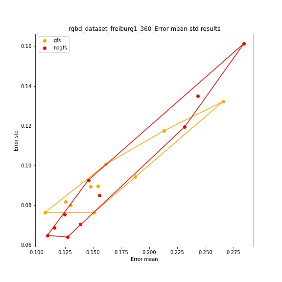

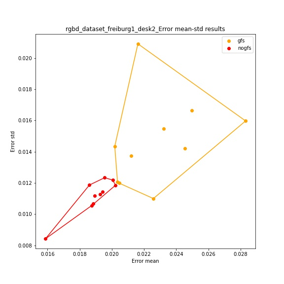

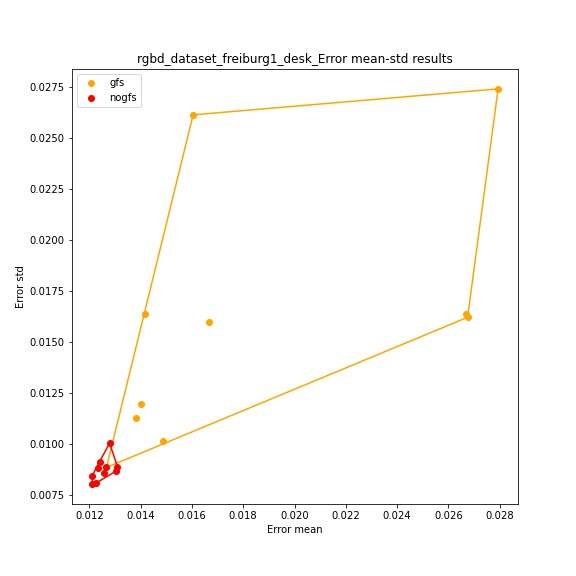

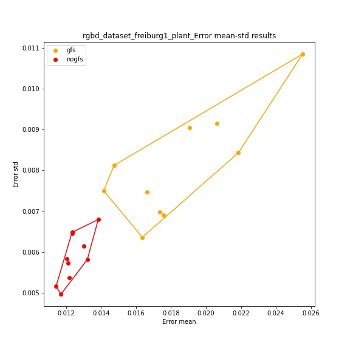

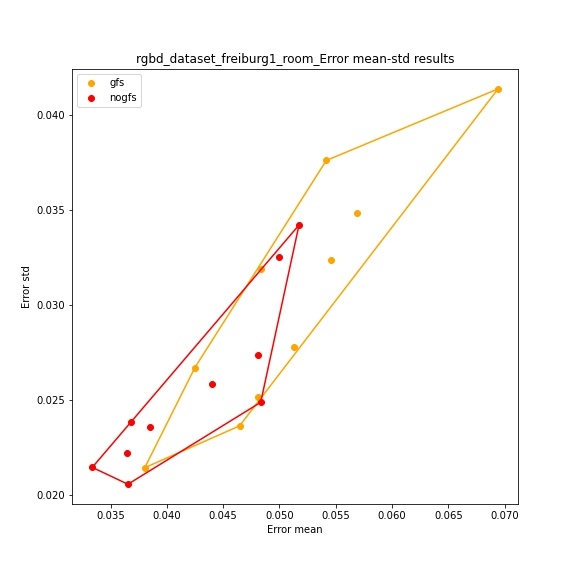

### Multi-index Hash

这里我们将对比同一个dataset上，将256位orb特征分为不同数量的block，所运行的结果进行对比。

#### Time Comparison

可以看出，分为4段和8段对于特征点的筛选较强，显著加速了localBA的过程。而分为16段和32段，由于匹配时间的上升，不仅没有加速，反而降低了速度。

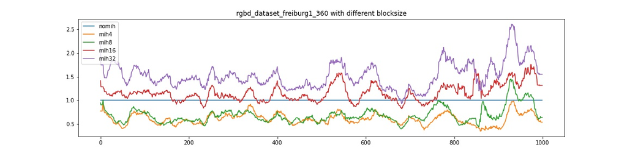

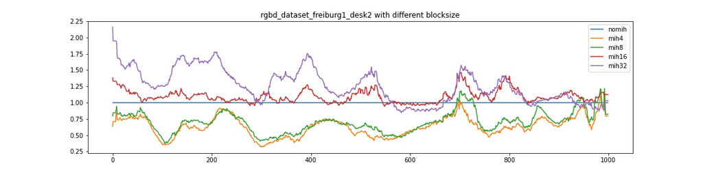

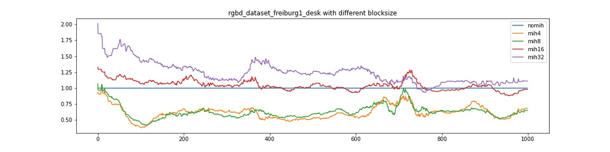

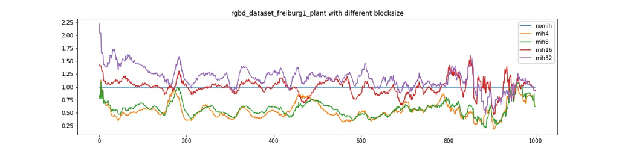

#### Points Selecting Comparison

这里我对localBA过程中，Map Points的数量做了对比。可以看出，分为4段和8段在特征点选取数量上是接近的，这也解释了为何上面的run time他们也有相似的表现。而分为16段和32段，map points数量和原始的就比较接近了，这也是为什么速度没有得到提升的原因，因为问题规模没有得到有效的减小。

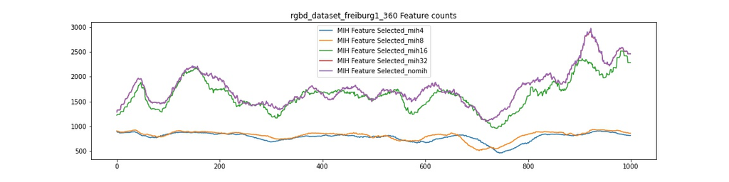

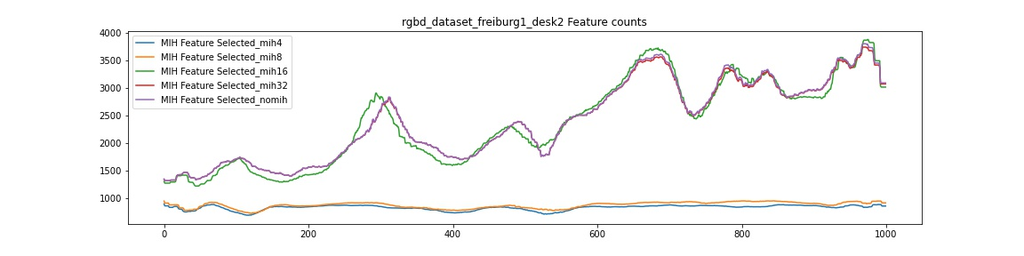

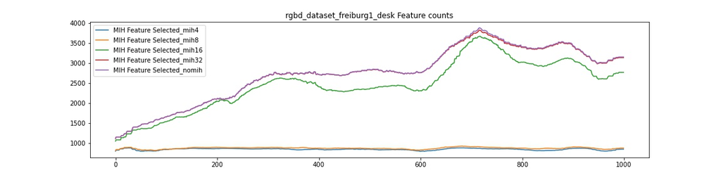

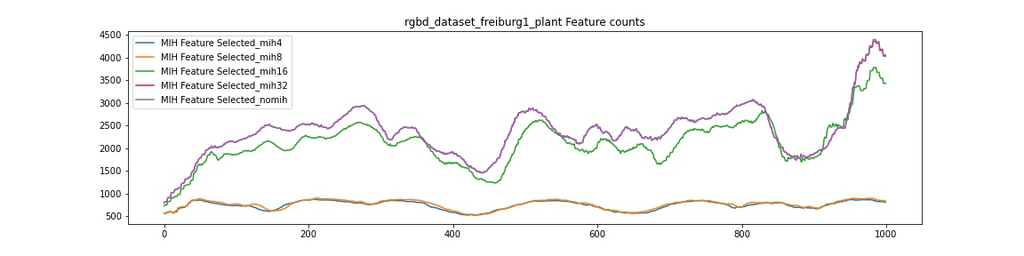

#### Error comparison

同样的，我们需要对精度进行测试。从精度结果上看，虽然分为4段和8段的运行速度是相近的，但是在精度上，8段的MIH可以比4段保持更好的误差精度，这提示我们，虽然它们筛选出的特征点数量相似，但质量是不一样的，从而在多个dataset上都呈现着牺牲一定的精度但获取了更好的速度的结果。16段和32段，正如我们所预想的，由于没有对特征点进行有效的减小，精度和原始ORB-SLAM2并没有明显的区分。

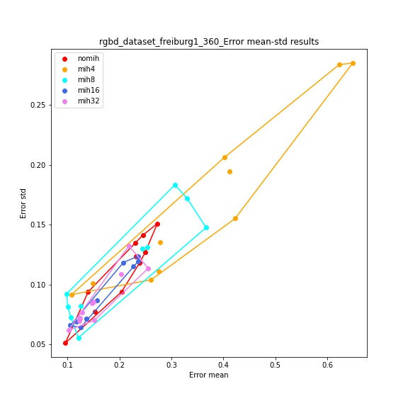

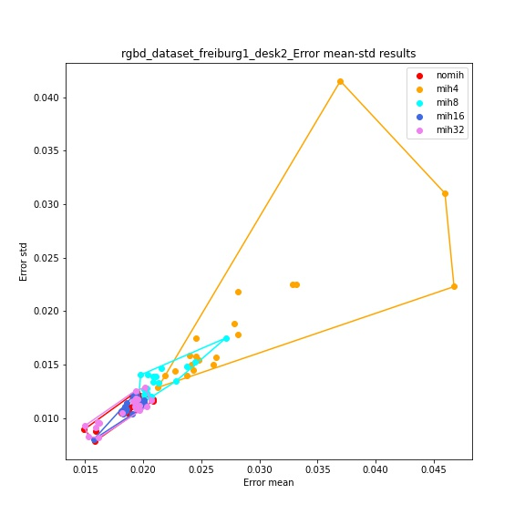

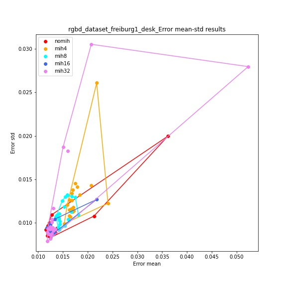

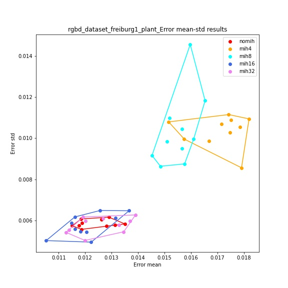

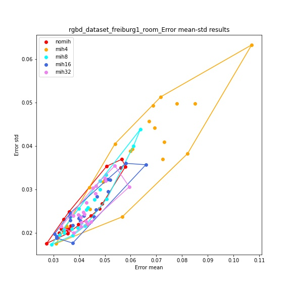

## Prospection

在这次paper的复现中，我主要复现了Good Feature Select以及Multi-index Hash两个改进。将结果总结如下。

- Good Feature Select 虽然从理论上有一定可行性，但是基于LogDet的greedy筛选策略看起来没有对结果进行有效的改进。其原因，从直觉上讲，可能是LogDet的筛选比例并没有很合适，需要对超参进行进一步的测试。
- Multi-index Hash则是获得了较好的符合预期的结果，即牺牲了一定的精度，获得了稳定的速度的提升。但和paper结果所提出的32段效果最好，结论不一致。其原因可能有两方面，第一，Multi-index Hash中特征点的取舍策略可能影响结果；第二，测试过程中发现4段和8段虽然筛选了特征点，但看起来已经达到了hash table所设置的最大特征点数量，这意味着随着特征点数量进一步上升，这样的Multi-index Hash很可能会丢失掉有效的特征点。

因此，对于Multi-index Hash的改进，我还会进行进一步的测试。同时，还将进行其他可行LocalBA的改进尝试。